# Customer Segmentation using K-Means Clustering

## Customer Segmentation using K-Means Clustering project

#### Objective:

The goal of this project is to segment customers into distinct groups based on their purchasing behaviors using K-Means clustering. By grouping customers based on similar features such as age, income, and spending scores, businesses can better understand customer profiles, target marketing strategies, and personalize services to improve customer retention.

#### Problem:

Retailers and service providers often face challenges in understanding their customer base. Without proper segmentation, marketing and sales strategies can be generalized, leading to inefficiencies. By clustering customers, businesses can create more targeted strategies that improve customer engagement and satisfaction, leading to higher sales and retention rates.

#### Step 1. Import Libraries and Dataset :

Dataset: For customer segmentation, a popular dataset is the Mall Customers Dataset (available on Kaggle). This dataset contains information like customer ID, age, gender, annual income, and spending score.

```python
#Install the Necessary Libraries
import pandas as pd
import numpy as np
import matplotlib.pyplot as plt
import seaborn as sns
from sklearn.cluster import KMeans
from sklearn.preprocessing import StandardScaler
```

```python
# Load the data
data = pd.read_csv('C:/Users/Lenovo/Downloads/Data Analysis Projects/Mall_Customers.csv')
print(data.head())  # View the first few rows
```

```
   CustomerID   Genre  Age  Annual Income (k$)  Spending Score (1-100)
0           1    Male   19                  15                      39
1           2    Male   21                  15                      81
2           3  Female   20                  16                       6
3           4  Female   23                  16                      77
4           5  Female   31                  17                      40
```

The data is loaded into the project, and you get an overview of the features, such as Age, Annual Income, and Spending Score. Understanding the dataset is crucial to performing appropriate data preprocessing.

#### Step 2. Data Preprocessing

Handle Missing Values:

Checking for missing values, understanding data types, and examining the distribution of features.

```python
# Check for missing values
print(data.isnull().sum())

# If there are missing values, drop them or impute with mean/median
data.dropna(inplace=True)
```

```
CustomerID                0
Genre                     0
Age                       0
Annual Income (k$)        0
Spending Score (1-100)    0
dtype: int64
```

```python
print(data.info())
```

```
<class 'pandas.core.frame.DataFrame'>
Int64Index: 200 entries, 0 to 199
Data columns (total 5 columns):
 #   Column                  Non-Null Count  Dtype
---  ------                  --------------  -----
 0   CustomerID              200 non-null    int64
 1   Genre                   200 non-null    object
 2   Age                     200 non-null    int64
 3   Annual Income (k$)      200 non-null    int64
 4   Spending Score (1-100)  200 non-null    int64
dtypes: int64(4), object(1)
memory usage: 9.4+ KB
None
```

```python
print(data.describe())
```

```
       CustomerID         Age  Annual Income (k$)  Spending Score (1-100)
count  200.000000  200.000000          200.000000              200.000000
mean   100.500000   38.850000           60.560000               50.200000
std     57.879185   13.969007           26.264721               25.823522
min      1.000000   18.000000           15.000000                1.000000
25%     50.750000   28.750000           41.500000               34.750000
50%    100.500000   36.000000           61.500000               50.000000
75%    150.250000   49.000000           78.000000               73.000000
max    200.000000   70.000000          137.000000               99.000000
```

Feature Selection:

```python
# Selecting only numerical features
X = data[['Annual Income (k$)', 'Spending Score (1-100)']]
```

Scale the Data:

K-Means is sensitive to scale, so we’ll standardize the data to ensure all features contribute equally.

```python
scaler = StandardScaler()
X_scaled = scaler.fit_transform(X)
```

Summary: Data preprocessing is crucial for handling missing data, selecting relevant features, and ensuring that the features are on the same scale to achieve better clustering results.

#### Step 3: Apply K-Means Clustering

Choosing the Right Number of Clusters (k):

K-Means requires specifying the number of clusters. The optimal number of clusters can be determined using the Elbow Method.

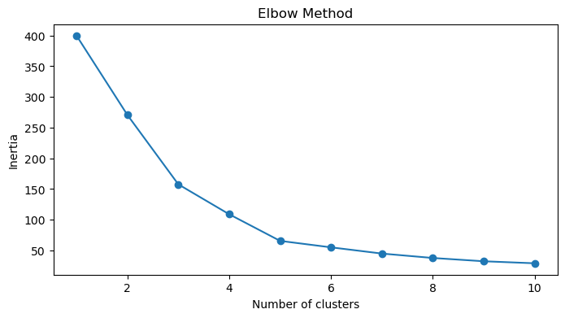

```python
inertia = []
for i in range(1, 11):
    kmeans = KMeans(n_clusters=i, random_state=42)
    kmeans.fit(X_scaled)
    inertia.append(kmeans.inertia_)

# Plot the results
plt.figure(figsize=(8, 4))
plt.plot(range(1, 11), inertia, marker='o')
plt.title('Elbow Method')
plt.xlabel('Number of clusters')
plt.ylabel('Inertia')
plt.show()
```

Fit the K-Means Model:

Create and fit a K-Means model with the chosen number of clusters.

```python
# Fit the model with the chosen k
kmeans = KMeans(n_clusters=5, random_state=42)
clusters = kmeans.fit_predict(X_scaled)

# Add the cluster labels to the original data
data['Cluster'] = clusters
print(data.head())
```

```
   CustomerID   Genre  Age  Annual Income (k$)  Spending Score (1-100)  \
0           1    Male   19                  15                      39
1           2    Male   21                  15                      81
2           3  Female   20                  16                       6
3           4  Female   23                  16                      77
4           5  Female   31                  17                      40

   Cluster
0        2
1        3
2        2
3        3
4        2
```

Summary: K-Means clustering is applied to segment customers into groups. The elbow method helps in selecting the optimal number of clusters (k), ensuring that the model finds a meaningful segmentation.

#### Step 4: Visualize the Clusters

2D Visualization: Use a 2D scatter plot to visualize how the customers are grouped based on the clusters

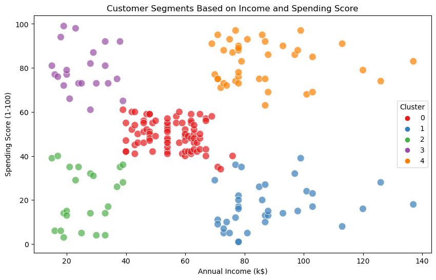

```python
plt.figure(figsize=(10, 6))
sns.scatterplot(x=data['Annual Income (k$)'], y=data['Spending Score (1-100)'], hue=data['Cluster'], palette='Set1', s=100, alpha=0.7)
plt.title('Customer Segments Based on Income and Spending Score')
plt.xlabel('Annual Income (k$)')
plt.ylabel('Spending Score (1-100)')
plt.legend(title='Cluster')
plt.show()
```

#### Step 5: Analyze and Interpret the Results

Examine Cluster Characteristics:

Use descriptive statistics to understand the characteristics of each cluster.

```python
cluster_summary = data.groupby('Cluster')[['Annual Income (k$)', 'Spending Score (1-100)']].mean()
print(cluster_summary)
```

```
         Annual Income (k$)  Spending Score (1-100)
Cluster
0                 55.296296               49.518519
1                 88.200000               17.114286
2                 26.304348               20.913043
3                 25.727273               79.363636
4                 86.538462               82.128205
```

We can interpret clusters as segments, for example:

1. High income, high spending: Potentially loyal or high-value customers.
2. Low income, low spending: Less engaged customers.
3. High income, low spending: Customers with potential for upselling.

Save the Results:

Save the labeled data to a new CSV file for further analysis.

```python
data.to_csv('customer_segments.csv', index=False)
```